# 50 lines of code to rebuild Claude Code in R

R+AI Conference 2026, *Joseph Barbier*

## About

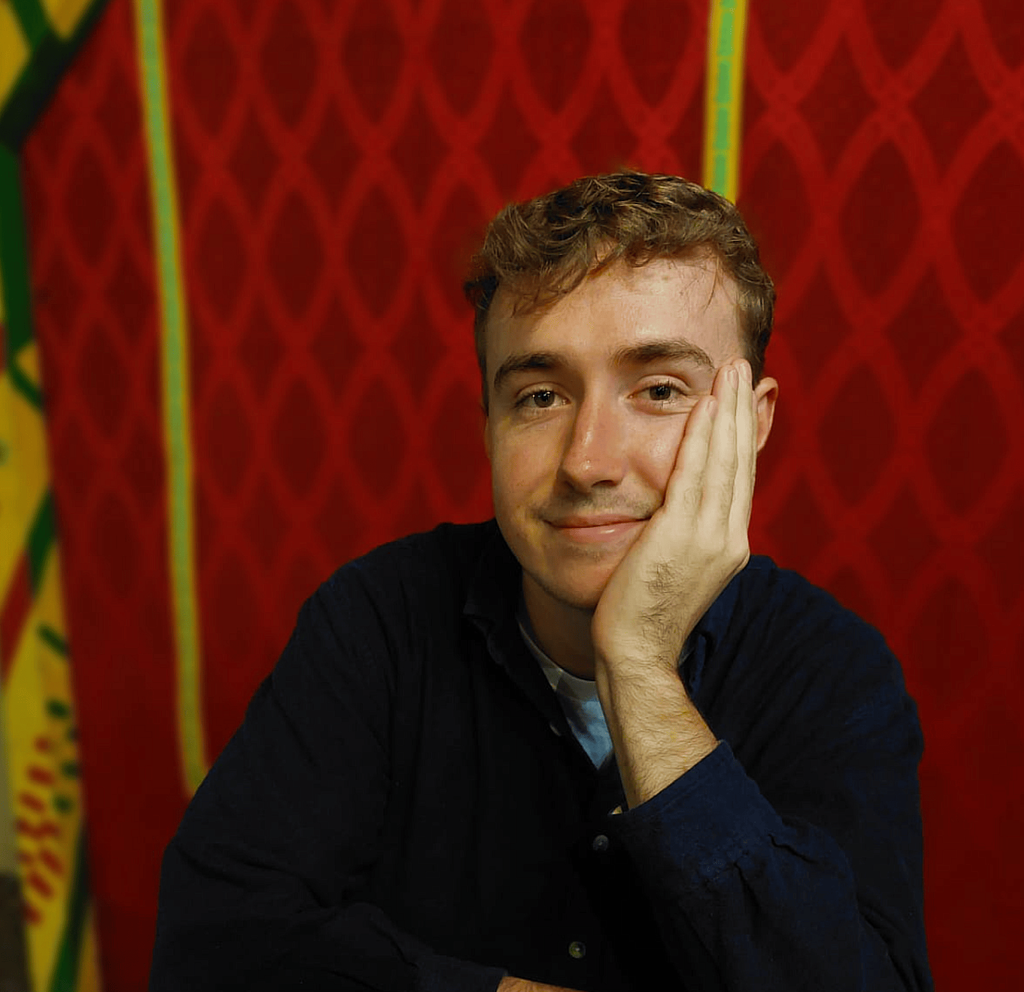

*Joseph*

barbierjoseph.com

ysunflower.com

**Consulting**: data, Typst

**Open source**: dataviz, Typst, accessibility

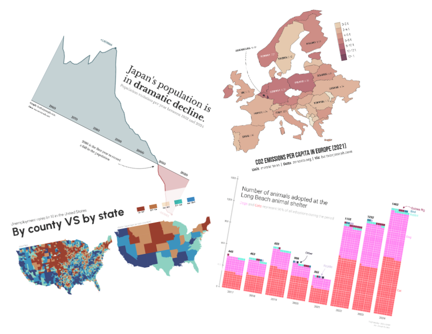

## Web app

[figure not shown]

[figure not shown]

- we forget important details
- we ignore things that could be relevant
- we need to copy-paste lots of code
- we’re lazy

## TUI (Terminal User Interface)

- where many devs already work
- no browser limitations (e.g., file access)
- faster
- doesn’t look as good

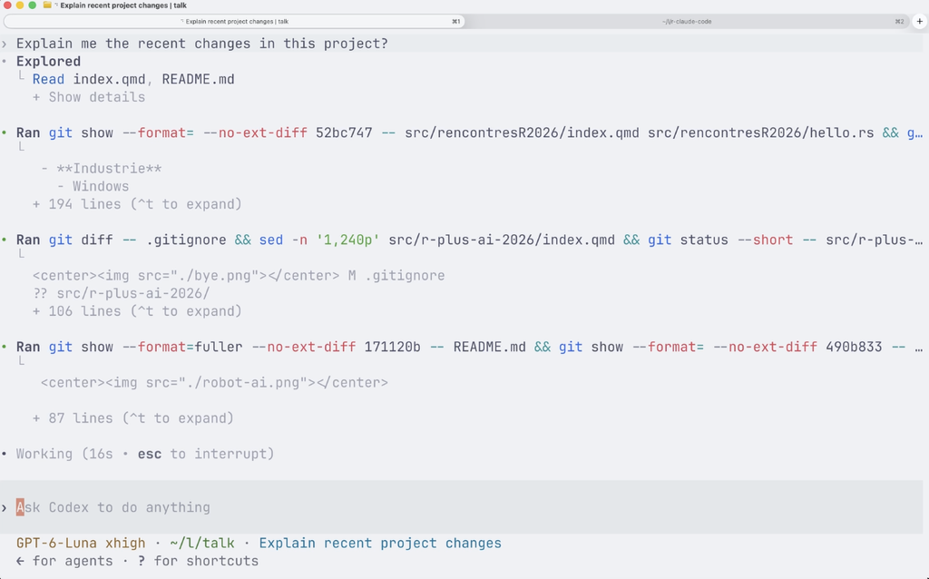

## TUI

They are written in Rust (Codex) or TypeScript (Claude Code, OpenCode, Pi)

How about R?

## **LLM** VS **chatbot** VS **agent**

### Definitions

- **LLM** = A model that takes text input and generates text output
- **Chatbot** = A conversational interface built around an LLM, where previous messages are included in the context of each new request
- **Agent** = An AI system that can use tools (APIs, browsers, code execution, etc.) to perform actions

### How can we create that in R?

- ✅ **LLM** = any AI API can work: OpenAI, Claude, Ollama, etc.
- ⚠️ **Chatbot** = an R console can do the work
- ❌ **Agent** = that’s what we need to build

[figure not shown]

## Chatbot

```r
library(ellmer)

chat <- chat_anthropic()
live_console(chat)
```

## Claude Code’s key tools

- List files
- Read files
- Write files
- Run commands

## Agent = chat with tools

```r
library(ellmer)

list_files <- tool(
  function(path = ".") list.files(path, recursive = TRUE, all.files = TRUE, no.. = TRUE),
  name = "list_files",
  description = "List files under a directory.",
  arguments = list(path = type_string("Directory to list.", required = FALSE))
)

chat <- chat_anthropic()
chat$register_tool(list_files)

live_console(chat)
```

## Claude Code’s key tools

- List files
- Read files
- Write files
- Run commands

Next: **read a file**

## Read files

```r
read_file <- tool(
  function(path) paste(readLines(path, warn = FALSE), collapse = "\n"),
  name = "read_file",
  description = "Read a text file.",
  arguments = list(path = type_string("Path to the text file to read."))
)
```

## Claude Code’s key tools

- List files
- Read files
- Write files
- Run commands

Next: **write a file**

## Write files

```r
ask <- \(x) isTRUE(utils::askYesNo(x))

write_file <- tool(
  function(path, text) {
    if (!ask(sprintf("Write %s?", path))) tool_reject()
    writeLines(text, path)
    sprintf("Wrote %s", path)
  },
  name = "write_file",
  description = "Write text to a file.",
  arguments = list(
    path = type_string("Path to write."),
    text = type_string("Full text content to write.")
  )
)
```

## Claude Code’s key tools

- List files
- Read files
- Write files
- Run commands

Next: **run commands**

```r
ask <- \(x) isTRUE(utils::askYesNo(x))
`%||%` <- \(x, y) if (is.null(x)) y else x

run_shell <- tool(
  function(command) {
    if (!ask(sprintf("Run `%s`?", command))) tool_reject()
    out <- suppressWarnings(system2("sh", c("-c", command), stdout = TRUE, stderr = TRUE))
    paste(c(sprintf("exit status: %s", attr(out, "status") %||% 0L), out), collapse = "\n")
  },
  name = "run_shell",
  description = "Run a shell command and return its output.",
  arguments = list(command = type_string("Shell command to run."))
)
```

## Claude Code’s key tools

```r
library(ellmer)

`%||%` <- \(x, y) if (is.null(x)) y else x
ask <- \(x) isTRUE(utils::askYesNo(x))

list_files <- tool(
  function(path = ".") list.files(path, recursive = TRUE, all.files = TRUE, no.. = TRUE),
  name = "list_files",
  description = "List files under a directory.",
  arguments = list(path = type_string("Directory to list.", required = FALSE))
)

read_file <- tool(
  function(path) paste(readLines(path, warn = FALSE), collapse = "\n"),
  name = "read_file",
  description = "Read a text file.",
  arguments = list(path = type_string("Path to the text file to read."))
)

write_file <- tool(
  function(path, text) {
    if (!ask(sprintf("Write %s?", path))) tool_reject()
    writeLines(text, path)
    sprintf("Wrote %s", path)
  },
  name = "write_file",
  description = "Write text to a file.",
  arguments = list(
    path = type_string("Path to write."),
    text = type_string("Full text content to write.")
  )
)

run_shell <- tool(
  function(command) {
    if (!ask(sprintf("Run `%s`?", command))) tool_reject()
    out <- suppressWarnings(system2("sh", c("-c", command), stdout = TRUE, stderr = TRUE))
    paste(c(sprintf("exit status: %s", attr(out, "status") %||% 0L), out), collapse = "\n")
  },
  name = "run_shell",
  description = "Run a shell command and return its output.",
  arguments = list(command = type_string("Shell command to run."))
)

chat <- chat_anthropic()
chat$register_tools(list(list_files, read_file, write_file, run_shell))
live_console(chat)
```

**47 lines of R code** for an Agent that can list/read/modify files and run commands

## Ending notes

⚠️ This isn’t a viable replacement!

Want to learn more? Implement missing features yourself!

- read CLAUDE.md
- security guardrails
- nicer UI
- …

**Code: [github.com/josephbarbierdarnal/r-claude-code](https://github.com/JosephBARBIERDARNAL/r-claude-code)**

Thanks!

Want to know more?

- let’s chat!
- LinkedIn: Joseph Barbier
- email: `joseph@ysunflower.com`
- slides: [github.com/josephbarbierdarnal/talk](https://github.com/JosephBARBIERDARNAL/talk/tree/main/src/rencontresR2026)

[figure not shown]